# Tema-09: Transformaciones Logarítmicas

Alonso Pizarro Lagunas

30/11/2021

# Escalas Logarítmicas

- Si estamos representando unos puntos $(x_i,y_i)_{i=1,...,n}$ en **escala semilogarítmica** observamos que siguen aproximadamente una recta. Es decir, los valores de $log(y)$ siguen una ley lineal en los valores de $x$.
- Se dice que y sigue una *ley exponencial en x*. Esto es, si $log(y) = ax + b$, entonces,
  $$y=10^{log(y)}$$
  o $y=10^{ax+b} = \alpha^x \beta$
- Por otro lado, si estamos representando unos puntos $(x_i,y_i)_{i =1,...,n}$ en **escala doble logarítmica** observamos que siguen una recta. Esto querrá decir que los valores $log(y)$ siguen una ley lineal aproximadamente en los valores $log(x)$.
- Se dice que y sigue una *ley aproximadamente potencial en x*. Esto es, si $log(y) = alog(x)+b$ se desprende que,
  $$y=10^{alog(x)+b} = x^{\alpha}\beta$$
  .

## Ejemplo

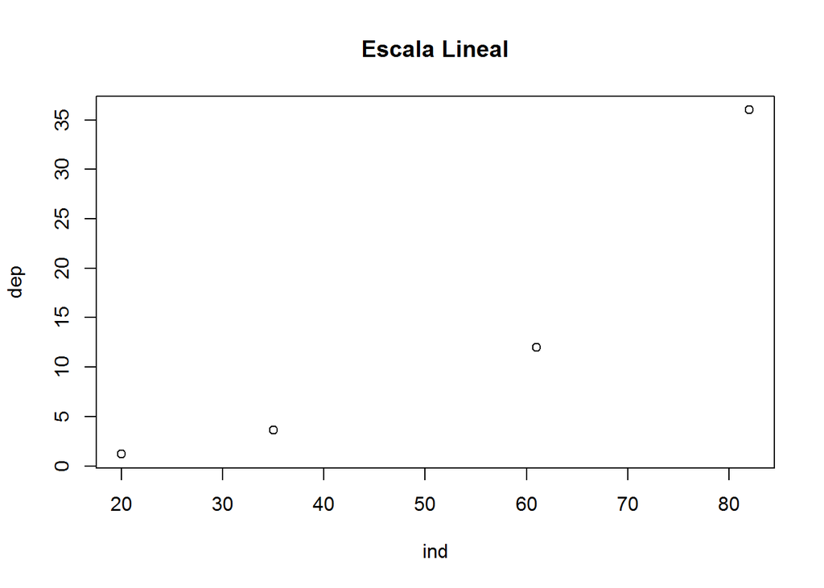

```r
dep = c(1.2,3.6,12,36)
ind = c(20,35,61,82)


plot(ind,dep, main = 'Escala Lineal')
```

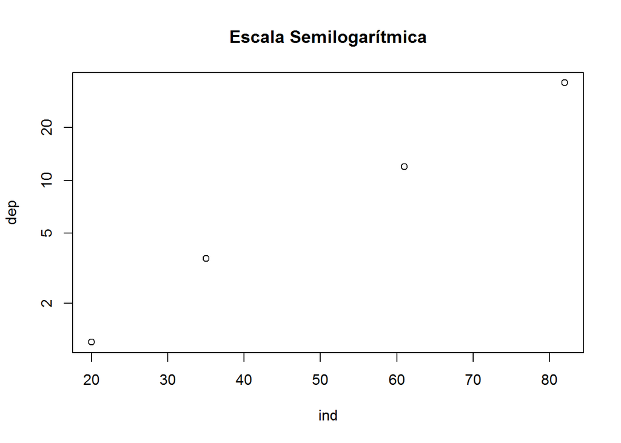

```r
plot(ind,dep,log = "y", main = 'Escala Semilogarítmica')
```

```r
lm(log10(dep)~ind)
```

```
##
## Call:
## lm(formula = log10(dep) ~ ind)
##
## Coefficients:
## (Intercept)          ind
##    -0.32951      0.02318
```

```r
summary(lm(log10(dep)~ind))$r.squared
```

```
## [1] 0.9928168
```

- Los coeficientes son, $\beta =$ -0.3295102 y $\alpha =$ 0.0231768.
- Como lo ilustra el modelo *semilog* escribimos como
  $$log(dep)=0.023 x -0.33$$
  , con lo cual, el modelo se expresaría
  $$dep = 10^{0.023} x \cdot 10^{-0.33}$$
- Dibujamos la curva con respecto a nuestro modelo, quedando,

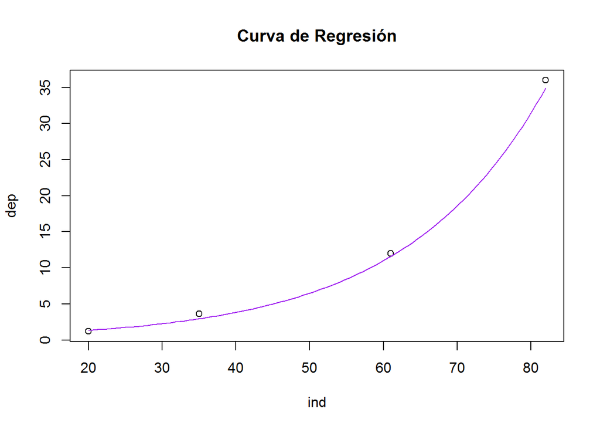

```r
# par(mfrow = c(1,2))
plot(ind,dep,main = "Curva de Regresión")
curve(1.054^x*0.468, add = T, col ="purple")
```

## Ejemplo con escalas doblelogarítmica

```r
tiempo = 1:10
gramos = c(0.097,0.709,2.698,6.928,15.242,29.944, 52.902,83.903,120.612,161.711)
d.f = data.frame(tiempo,gramos)
```

- Graficamos los datos con los tres modelos

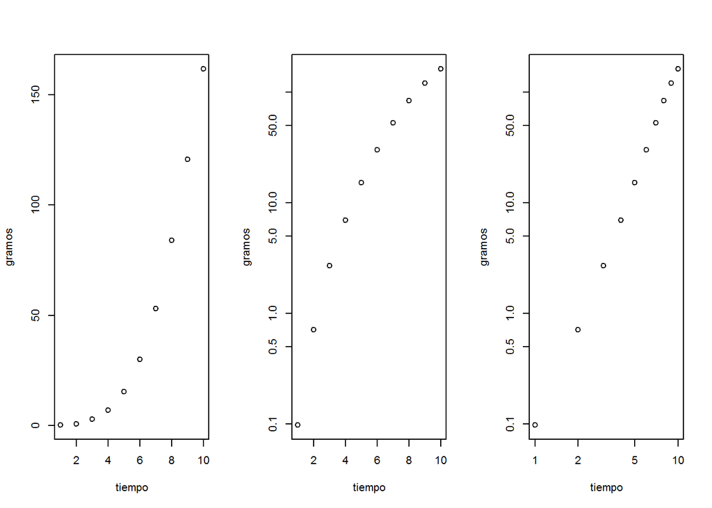

```r
 par(mfrow =c(1,3))
 plot(d.f)
 plot(d.f, log = "y")
 plot(d.f, log = "xy")
```

- Como muestran los datos, en el tercer gráfico al parecer hay una relación potencial entre los gramos y el tiempo.
- Aplicando el modelo de escala doble logarítmica:

```r
lm(log10(gramos)~log10(tiempo))
```

```
##
## Call:
## lm(formula = log10(gramos) ~ log10(tiempo))
##
## Coefficients:
##   (Intercept)  log10(tiempo)
##        -1.093          3.298
```

```r
beta = coefficients(summary(lm(log10(gramos)~log10(tiempo))))[[1]]
alpha = coefficients(summary(lm(log10(gramos)~log10(tiempo))))[[2]]
r.2 = summary(lm(log10(gramos)~log10(tiempo)))$r.squared
```

- El modelo de escala doble logaritmico que se obtuvo corresponde a
  $$log(gramos) = 3.298 log(tiempo) + -1.093$$
  .
- El modelo potencial estimado es $y = tiempo^{3.298}\cdot 10^{-1.093}$

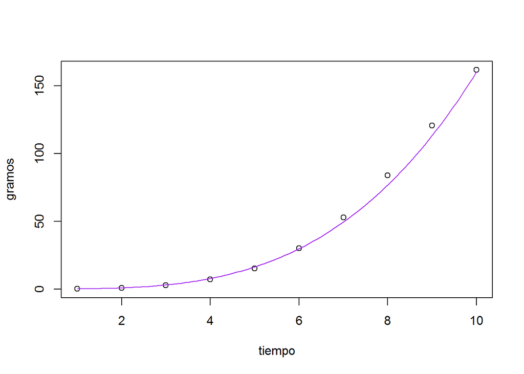

```r
plot(d.f)
curve(x^round(alpha,3)* 10^round(beta,3), col='purple', add= T)
```